# Quiz 2 Mineria de Datos

David Moreno

2024-02-28

### Universidad de los Andes Minería de Datos – MIIA 4200

Profesor: Rafael Amaya Gómez

# Punto 1

El dataset Wage (librería ISLR) trabajado en clase tiene otras variables no exploradas como el estado marital (maritl), o la clase de trabajo (jobclass) y otras. Explore las relaciones entre por lo menos estas dos variables con la variable respecto a wage, usando técnicas de ajuste no lineal para ajustar modelos flexibles a los datos. Cree figuras de los resultados obtenidos y describa un resumen de sus hallazgos.

```r
#import the necessary libraries for data manipulation and visualization
library(tidyverse)
library(ggplot2)
library(tidyr)


load("auto.Rdata")
load("wage.Rdata")

head(Wage)
```

```
##        year age           maritl     race       education             region
## 231655 2006  18 1. Never Married 1. White    1. < HS Grad 2. Middle Atlantic
## 86582  2004  24 1. Never Married 1. White 4. College Grad 2. Middle Atlantic
## 161300 2003  45       2. Married 1. White 3. Some College 2. Middle Atlantic
## 155159 2003  43       2. Married 3. Asian 4. College Grad 2. Middle Atlantic
## 11443  2005  50      4. Divorced 1. White      2. HS Grad 2. Middle Atlantic
## 376662 2008  54       2. Married 1. White 4. College Grad 2. Middle Atlantic
##              jobclass         health health_ins  logwage      wage
## 231655  1. Industrial      1. <=Good      2. No 4.318063  75.04315
## 86582  2. Information 2. >=Very Good      2. No 4.255273  70.47602
## 161300  1. Industrial      1. <=Good     1. Yes 4.875061 130.98218
## 155159 2. Information 2. >=Very Good     1. Yes 5.041393 154.68529
## 11443  2. Information      1. <=Good     1. Yes 4.318063  75.04315
## 376662 2. Information 2. >=Very Good     1. Yes 4.845098 127.11574
```

Prmiero vemos de qué tipo son nuestras variables

```r
str(Wage)
```

```
## 'data.frame':    3000 obs. of  11 variables:
##  $ year      : int  2006 2004 2003 2003 2005 2008 2009 2008 2006 2004 ...
##  $ age       : int  18 24 45 43 50 54 44 30 41 52 ...
##  $ maritl    : Factor w/ 5 levels "1. Never Married",..: 1 1 2 2 4 2 2 1 1 2 ...
##  $ race      : Factor w/ 4 levels "1. White","2. Black",..: 1 1 1 3 1 1 4 3 2 1 ...
##  $ education : Factor w/ 5 levels "1. < HS Grad",..: 1 4 3 4 2 4 3 3 3 2 ...
##  $ region    : Factor w/ 9 levels "1. New England",..: 2 2 2 2 2 2 2 2 2 2 ...
##  $ jobclass  : Factor w/ 2 levels "1. Industrial",..: 1 2 1 2 2 2 1 2 2 2 ...
##  $ health    : Factor w/ 2 levels "1. <=Good","2. >=Very Good": 1 2 1 2 1 2 2 1 2 2 ...
##  $ health_ins: Factor w/ 2 levels "1. Yes","2. No": 2 2 1 1 1 1 1 1 1 1 ...
##  $ logwage   : num  4.32 4.26 4.88 5.04 4.32 ...
##  $ wage      : num  75 70.5 131 154.7 75 ...
```

Vemos que el año es un entero, el dataframe tiene 3000 observaciones con 11 variables para el caso del quiz nos conviene ver las dos variables que estamos considerando que son jobclass y maritl, vemos que la variable jobclass es un factor que tienee 2 niveles y que maritl tiene 5 niveles, eso quiere decir el número de categorias en variable.

Por lo tanto una buena forma de comenzar el análisis es hacer una gráfica por cada categoria en un box plot mostrando la variable wage

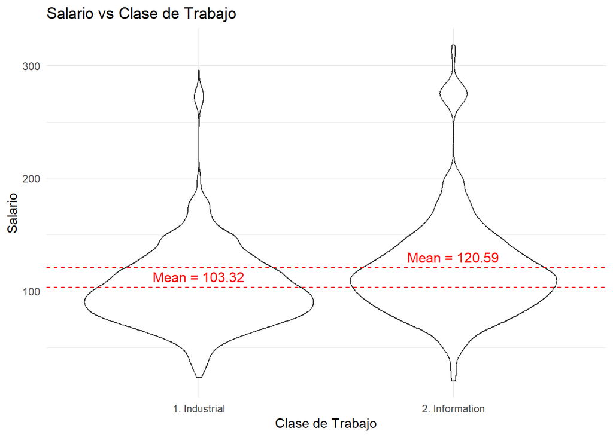

```r
# Calcular el salario promedio por clase de trabajo
mean_wage <- Wage %>%
  group_by(jobclass) %>%
  summarise(mean_wage = mean(wage, na.rm = TRUE))

# Graficar con el salario promedio
ggplot(Wage, aes(x = jobclass, y = wage)) +
  geom_violin() +  # Agregar gráfico de violín
  geom_hline(data = mean_wage, aes(yintercept = mean_wage), color = "red", linetype = "dashed") +  # Línea horizontal para el salario promedio
  geom_text(data = mean_wage, aes(x = jobclass, y = mean_wage, label = paste("Mean =", round(mean_wage, 2))),
            vjust = -0.5, color = "red", size = 4) +  # Texto para mostrar el salario promedio
  labs(title = "Salario vs Clase de Trabajo", x = "Clase de Trabajo", y = "Salario") +  # Etiquetas de título y ejes
  theme_minimal()  # Estilo del gráfico
```

Al analizar el gráfico, se destaca un patrón interesante. En primer lugar, al observar las formas tipo violín, se nota que las personas en el área de información tienden a tener salarios más altos, con una media alrededor de 120, mientras que en el área industrial la media está aproximadamente en 103. Además, llama la atención la presencia de algunos valores atípicos en ambas columnas, especialmente más prominentes en el área de información, lo que sugiere que, en general, aquellos en el campo de la información obtienen salarios más altos. Además, parece que estos casos de salarios excepcionalmente altos son más frecuentes en el área de información que en la industrial.

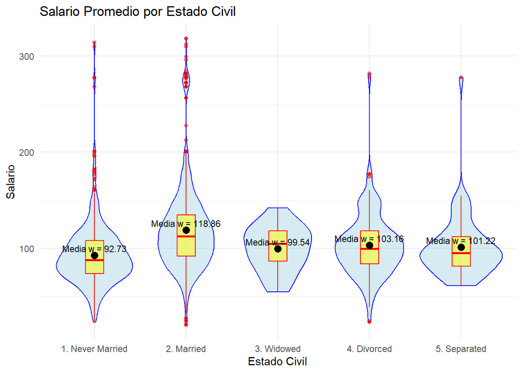

```r
# Calcular el salario promedio por estado civil
mean_wage_marital <- Wage %>%
  group_by(maritl) %>%
  summarise(mean_wage = mean(wage, na.rm = TRUE))

# Graficar el salario promedio por estado civil con violin plot y boxplot
ggplot(Wage, aes(x = maritl, y = wage)) +
  geom_violin(color = "blue", fill = "lightblue", alpha = 0.5) +  # Agregar gráfico de violín
  geom_boxplot(width = 0.2, color = "red", fill = "yellow", alpha = 0.5) +  # Agregar gráfico de boxplot
  geom_point(data = mean_wage_marital, aes(y = mean_wage), color = "black", size = 3) +  # Puntos para mostrar el salario promedio
  geom_text(data = mean_wage_marital, aes(y = mean_wage, label = paste("Media w =", round(mean_wage, 2))),
            vjust = -0.5, color = "black", size = 3) +  # Texto para mostrar el salario promedio
  labs(title = "Salario Promedio por Estado Civil", x = "Estado Civil", y = "Salario") +  # Etiquetas de título y ejes
  theme_minimal()  # Estilo del gráfico
```

Observamos que la media de los individuos que nunca se han casado es la más baja en comparación con los demás estados civiles. Sin embargo, observamos valores atípicos en los salarios más altos. Para las personas casadas, vemos que la media es la más alta con 118, y que existe una alta tendencia a tener valores atípicos más pronunciados en los salarios altos. Para las personas viudas, vemos que no hay valores atípicos y en general los datos están bastante centrados en la media. Para las personas divorciadas, vemos que tienen una media de alrededor de 104 con algunos valores altos pero menos pronunciados que en los grupos de personas nunca casadas y casadas

```r
model_gam <- gam(wage ~ s(maritl, bs = "fs"), data = Wage)

# Resumen del modelo para ver significancia y efectos
summary(model_gam)
```

```
##
## Family: gaussian
## Link function: identity
##
## Formula:
## wage ~ s(maritl, bs = "fs")
##
## Parametric coefficients:
##             Estimate Std. Error t value Pr(>|t|)
## (Intercept)  104.278      2.896   36.01   <2e-16 ***
## ---
## Signif. codes:  0 '***' 0.001 '**' 0.01 '*' 0.05 '.' 0.1 ' ' 1
##
## Approximate significance of smooth terms:
##             edf Ref.df  F p-value
## s(maritl) 2.628      4 53  <2e-16 ***
## ---
## Signif. codes:  0 '***' 0.001 '**' 0.01 '*' 0.05 '.' 0.1 ' ' 1
##
## R-sq.(adj) =  0.0685   Deviance explained = 6.93%
## GCV =   1624  Scale est. = 1622      n = 3000
```

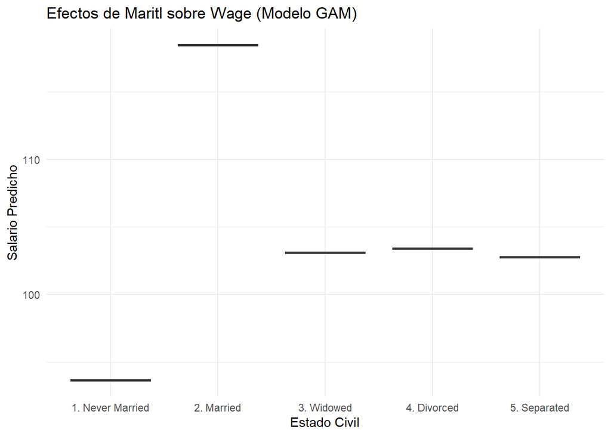

```r
# Para visualizar los efectos de 'maritl', que es categórica, sobre 'wage':
# La función 'plot()' de mgcv puede no ser directamente aplicable para efectos categóricos de la manera más informativa.
# Sin embargo, podemos obtener los efectos predichos del modelo y visualizarlos manualmente

# Obtener predicciones para cada nivel de 'maritl'
Wage$predicted_wage <- predict(model_gam, type = "response")

# Gráfico de los efectos de 'maritl' sobre 'wage'
ggplot(Wage, aes(x = maritl, y = predicted_wage)) +
  geom_boxplot() +
  labs(title = "Efectos de Maritl sobre Wage (Modelo GAM)", x = "Estado Civil", y = "Salario Predicho") +
  theme_minimal()
```